# Nazareno_B_Chavez_A

2023-03-20

Introduction:

Within the U.S., gender inequities have persisted across societal institutions causing disparities in multiple life indexes. Inequities along gender lines have persisted across professions. Research from the Pew Research Center analysis illustrates on average, women make 82 cents to a man’s dollar in 2022. Within the financial industry, the U.S. Bureau of Labor Statistics states for every man’s dollar, a woman earns 62 cents. Within the legal services industry, every man’s dollar earned is equivalent to 78 cents earned by a woman. (U.S Bureau of Labor Statistics). For every dollar a man earns in real estate, a woman earns 64 cents. (Chicago Association of Realtors). As researched, wage gaps exist on gendered lines across industries. Considering these statistics, we seek to research if gender wage disparities exist within the medical field, focusing on three key professions: Physicians and Surgeons and Registered Nurses.

If such disparities are found, we seek to understand the catalysts and contributing factors to the inequities. Regarding the macro field of gender inequities within the U.S., the American Association of University Women states earning potential inequities, decreased retirement stability, mental health instability, and occupational gendered segregation as a non-exhaustive list of consequences of gender wage gaps. Data from the U.S Bureau of Labor Statistics indicate that the gender wage gap has lessened over the decades, however, it still exists. Its existence illustrates the importance of its study as findings can lead to solutions. Through analyzing the contributors to the gender wage gap, initiatives for gender equality can be devised and implemented across sectors.

Economic gap solutions can be designed through the crucial study of its causes. All in all, social justice, inclusion, and diversity can be effective results of investment in gender studies. Within our research project, we will analyze data from the Bureau of Labor Statistics which collected income data from various occupations of U.S. citizens in January 2015, to answer the question whether or not there are differences in wages between female and male Physicians, Surgeons, and Registered Nurses? From this analysis we will investigate how a worker’s gender is the determining factor for wage gaps in these occupations.

Literature Review:

Research Findings For our research project we decided to study the gender wage gap within the US. In the United States, the gender wage gap has always been present within the workforce, and on average women currently make .82 cents to a man’s dollar and among physicians this statistic does worsen. Our research question is, How do gender norms and stereotypes contribute to the gender wage gap among male and female physicians?

This is an important topic to research because of its relevance and its financial effects on everyone, in particular women, but also men as it puts a burden on both within and outside of the workforce. Your wages impact your current economic status and once you retire your social security will have been significantly impacted by lost wages. While the gender wage gap has lessened over the decades, it is still present and with the recent worldwide pandemic, most women have taken a major hit to their incomes as they have had to make financial and career sacrifices to take care of their household. Additionally, the gender wage gap has been studied extensively and there are many findings accounting for this situation but focusing on gender norms and stereotypes, with how unconscious and effective they can be, will highlight how the causes of the gender wage gap are not only systemic but individualistic. The project speaks to the socio-cultural research areas as it takes into account social norms and their economic consequences. We’re planning to look for data on Kaggle which has two data sets having to do with the gender wage gap as well as incomes by career and gender.

Literature Review:

From our data analysis and research we find that there is a gender wage gap between male and female workers within the fields of Physicians, surgeons, and Registered Nurses. As for why this disparity exists we conclude that gender, whether the worker is female or male, is the major contributing factor to this disparity. In the article, “Physician Work Hours and the Gender Pay Gap - Evidence from Primary Care,” the authors Ganguli et al, “…conducted a cross-sectional analysis of 24.4 million primary care office visits in 2017 and performed comparisons between female and male physicians in the same practices.” (Ganguli et al, 2020). They found that female PCPs (Primary Care Physicians) earned 10.9% less revenue than their male counterparts. Even after adjusting for primary care physicians’ patients and visit characteristics the researchers found that female physicians still had to spend 15.7% more time with patients just to earn as much as males.

This article aids our research in that it shows how even when other factors, aside from gender, are adjusted for, female physicians still earn less and have to spend more time with patients just to earn as much as men. In the article, “Male Physicians Earn More than Women in Primary and Specialty Care,” the author Celli Horstman states that for every dollar a male physician earns, female physicians earn .74 cents. The author then reviews various research papers that have been conducted to account for this wage disparity. The reasons vary from certain specialties costing more than others to the way the U.S. healthcare system is set up which all contribute in one way or another to the gender wage gap. This article aids our research in that it contextualizes our findings from the data analysis we conducted. It allows us to understand other determinants that also contribute to the wage gap, as well as solutions that have been proposed in order to deal with these disparities.

In the article, “Inequity and Women Physicians: Time to Change Millenia of Societal Beliefs,” the authors Connie Newman, MD et al, find that “Biases based on gender stereotypes can negatively affect the careers of women in science and medicine.” (Newman et al, 2020). They then go on to list out the negative impact of gender biases which include, career advancement, financial considerations, as well as psychological challenges. While they list out these negative impacts they all, including the financial considerations, are caused by gender biases that are influenced by gender stereotypes. Gender is the driving factor for wage gaps and this article allows us to historically contextualize this issue as well as highlight the implications and consequences of being a woman in the medical and science career path. A possible critique of our research is that gender may not be the determining factor for the wage gap differences between men and women.

In the study, “Differences in Physician Income by Gender in a Multiregion ’’ Survey, the authors’ findings from their survey reveal that while male Physicians do make more than women, male physicians also tend to work more total hours, and have more total patient care hours. Women, on average, tend to go into primary care which tends to pay less than other fields of work. They found that adjusting for other factors, “…male physicians’ incomes were $27,404 greater than female physicians’ incomes.” (Apaydin et al, 2018). Despite these findings, we still maintain that gender is a determining factor in the wage gaps because of certain social factors such as gender roles which make it so that women are more likely to work less in order to care for outside-of-work issues. For example, the Motherhood Penalty “…is a term coined to describe the discrimination mothers experience in the workplace….Motherhood has been shown to be associated with decreased pay, low perceived competence, and less commitment to one’s career.”(Polan et al, 2022).

Motherhood is a uniquely female experience and it is not seen positively within the workforce but despite this, it has been found that working mothers are more productive than peers who do not have children. Parenthood though does not have the same effect on males, as instead for them there is a Fatherhood Bonus, which is the notion that men are likely to get a wage increase when they have children. In The Fatherhood Bonus and the motherhood penalty: Parenthood and the gender gap in pay, the author states that they found, “…that, all else equal, fatherhood increases men’s earnings by over 6%.”(Budig, 2014). Overall, there are certain social factors that have to do with gender that can influence why women may work less because of certain prejudices that higher-ups in the workforce may perpetuate thereby making it so that women earn less than men.

This penalty of motherhood can also apply, although not as drastically to women without children as seen in Catherine J. Turco’s paper, “Cultural Foundations of Tokenism: Evidence from the Leveraged Buyout Industry. In this research paper, Turco finds that of the women interviewed, all of them whether or not they were a mother “…raised the issue of motherhood as an obstacle to women’s advancement…”(Turco, 2010). One of the women interviewed states that she was questioned on whether or not she was planning to have a child, which she knew would impact whether or not she would be someone that others would invest time, effort, and apprenticeship opportunities within the Leverage Buyout Industry. While this may be a field of work different from our research focus this sort of mindset pervades throughout other fields, including the medical field. The medical field is highly competitive and requires many hours of devotion, and parenthood, a time-consuming activity that is still viewed as being something the mothers should devote most of their time to as opposed to fathers, this mindset makes it easier to simply give female workers fewer hours to work because it is assumed they will take time off either way. Overall, gender is a powerful driving force that contributes to creating environments where being a female worker has financial repercussions and the gender wage gap continues to exist.

Data and Methods: For our research we used two datasets which we retrieved from the Bureau of Labor Statistics, the first data set included the median weekly income of 535 different occupations from American citizens as of January 2015. The data has been broken down into female and male workers. We retrieved this dataset from Kaggle and it was named “U.S. Incomes by Occupation and Gender”. We used this data to compare the incomes of Physicians and surgeons (the data for these occupations are collected in the same row) and Registered Nurses which is the focus of our research paper. The second dataset was of household data and annual averages of employed persons which took into account median weekly earnings of full-time wage and salary workers by detailed occupation and sex. Our research question asks if there is a gender pay gap and we research this primarily through the occupations of physicians and surgeons, nurses while also using education administrators, elementary and middle school teachers to further substantiate how pervasive the gender wage gap is in different occupations. These datasets allow us to extract data and compare pay based on different fields of work within the medical field and gender which answers our research question.

The data is divided into 7 columns with occupation, number of workers male and female in the thousands (All_worker), median weekly income of male and female workers in USD (All_weekly), number of male workers in thousands (M_workers), median weekly income of male workers in USD (M_weekly), number of female workers in thousands (F_workers), median weekly income of female workers in USD (F_weekly). We hypothesize that male workers in each occupation will have a higher median weekly income than female workers. As for the methods we decided to extract the rows labeled “Physicians and surgeons” and “Registered Nurses” creating two tables that have data on the gender composition of each occupation, their median weekly income combined and divided by gender so that we can compare them and answer our research question. The second dataset is divided into 8 columns specifying total median weekly earnings for box female and male workers, sex composition of each occupation and weekly median earnings divided by sex. For our purposes we extracted the rows``Education Administrators’ ’ and “Elementary and Middle School teachers” and columns on gender composition and median weekly earnings of each sex.

We created four bar plots, one for Physicians and surgeons, Registered Nurses, Education Administrators, and Elementary and Middle School teachers where the independent variable is gender composition and the dependent variable is median weekly income. We will then compare the median weekly incomes to be able to answer whether or not there is a wage gap between men and women in these occupations. With our research findings, we’ll explore the reasons and explanations for the disparities found while focusing primarily on how gender is a determining factor for wage gaps. This will help us answer our research question because we are able to compare how in different occupations the gender wage gaps persist. Although the data shows that men and women do have significant wage differences we acknowledge the limitation that may cause errors: sample size, confounders such as information of different types of hospitals or positions physicians may work under, and other factors may also impact the wage gap that is simply not taken into account in our dataset.

```r
getwd()
```

```
## [1] "/Users/alejandrachavez/Downloads"
```

```r
setwd("/Users/alejandrachavez/Downloads")
```

```r
library(readr)
```

```r
library(tidyverse)
gender_pay_gap <- read_csv("~/Downloads/inc_occ_gender.csv") %>% view()
readr::read_csv("inc_occ_gender.csv")
```

```
## # A tibble: 558 × 7
##    Occupation                    All_w…¹ All_w…² M_wor…³ M_wee…⁴ F_wor…⁵ F_wee…⁶
##    <chr>                           <dbl> <chr>     <dbl> <chr>     <dbl> <chr>
##  1 ALL OCCUPATIONS                109080 809       60746 895       48334 726
##  2 MANAGEMENT                      12480 1351       7332 1486       5147 1139
##  3 Chief executives                 1046 2041        763 2251        283 1836
##  4 General and operations manag…     823 1260        621 1347        202 1002
##  5 Legislators                         8 Na            5 Na            4 Na
##  6 Advertising and promotions m…      55 1050         29 Na           26 Na
##  7 Marketing and sales managers      948 1462        570 1603        378 1258
##  8 Public relations and fundrai…      59 1557         24 Na           35 Na
##  9 Administrative services mana…     170 1191         96 1451         73 981
## 10 Computer and information sys…     636 1728        466 1817        169 1563
## # … with 548 more rows, and abbreviated variable names ¹All_workers,
## #   ²All_weekly, ³M_workers, ⁴M_weekly, ⁵F_workers, ⁶F_weekly
```

```r
gender_pay_gap[143,]
```

```
## # A tibble: 1 × 7
##   Occupation                     All_w…¹ All_w…² M_wor…³ M_wee…⁴ F_wor…⁵ F_wee…⁶
##   <chr>                            <dbl> <chr>     <dbl> <chr>     <dbl> <chr>
## 1 Elementary and middle school …    2806 974         543 1077       2262 957
## # … with abbreviated variable names ¹All_workers, ²All_weekly, ³M_workers,
## #   ⁴M_weekly, ⁵F_workers, ⁶F_weekly
```

```r
library(tidyr)
```

Physicians and surgeons

```r
gender_pay_gap[178,]
```

```
## # A tibble: 1 × 7
##   Occupation              All_workers All_weekly M_wor…¹ M_wee…² F_wor…³ F_wee…⁴
##   <chr>                         <dbl> <chr>        <dbl> <chr>     <dbl> <chr>
## 1 Physicians and surgeons         740 1824           457 1915        283 1533
## # … with abbreviated variable names ¹M_workers, ²M_weekly, ³F_workers,
## #   ⁴F_weekly
```

Registered Nurses

```r
gender_pay_gap[191,]
```

```
## # A tibble: 1 × 7
##   Occupation        All_workers All_weekly M_workers M_weekly F_workers F_weekly
##   <chr>                   <dbl> <chr>          <dbl> <chr>        <dbl> <chr>
## 1 Registered nurses        2382 1116             278 1222          2104 1098
```

```r
library("readxl")
```

```r
second_gender_pay <- read_xlsx("~/Downloads/cpsaat39.xlsx") %>% view()
```

Education Administrators:

```r
second_gender_pay[29, 4:5]
```

```
## # A tibble: 1 × 2
##   ...4  ...5
##   <chr> <chr>
## 1 282   1585
```

```r
second_gender_pay[29, 6:7]
```

```
## # A tibble: 1 × 2
##   ...6  ...7
##   <chr> <chr>
## 1 496   1252
```

Bar plots:

Physicians and Surgeons:

```r
data_p <- tibble(
  gender = c("female", "male"),
  no_people = c(283, 457),
  median_inc = c(1533, 1915)
)
```

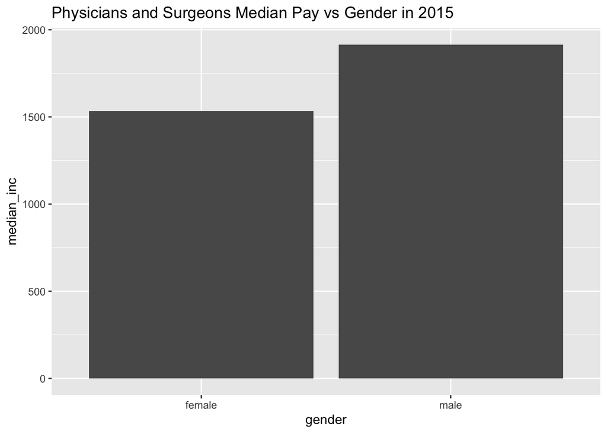

```r
data_p %>%
  ggplot(aes(x = gender, y = median_inc)) +
  geom_col() +
  ggtitle("Physicians and Surgeons Median Pay vs Gender in 2015")
```

Registered Nurses:

```r
data_n <- tibble(
  gender = c("female", "male"),
  no_people = c(2104, 278),
  median_inc = c(1098, 1222)
)
```

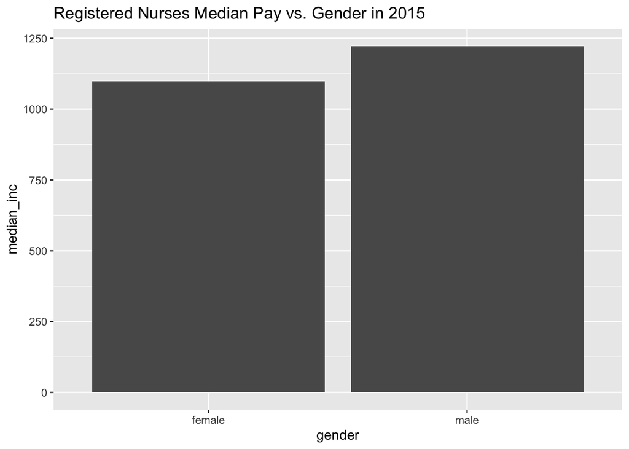

```r
data_n %>%
  ggplot(aes(x = gender, y = median_inc)) +
  geom_col() +
  ggtitle("Registered Nurses Median Pay vs. Gender in 2015")
```

Education Administrators:

```r
data_E_A <- tibble(
  gender = c("female", "male"),
  no_people = c(496, 282),
  median_inc = c(1252, 1585)
)
```

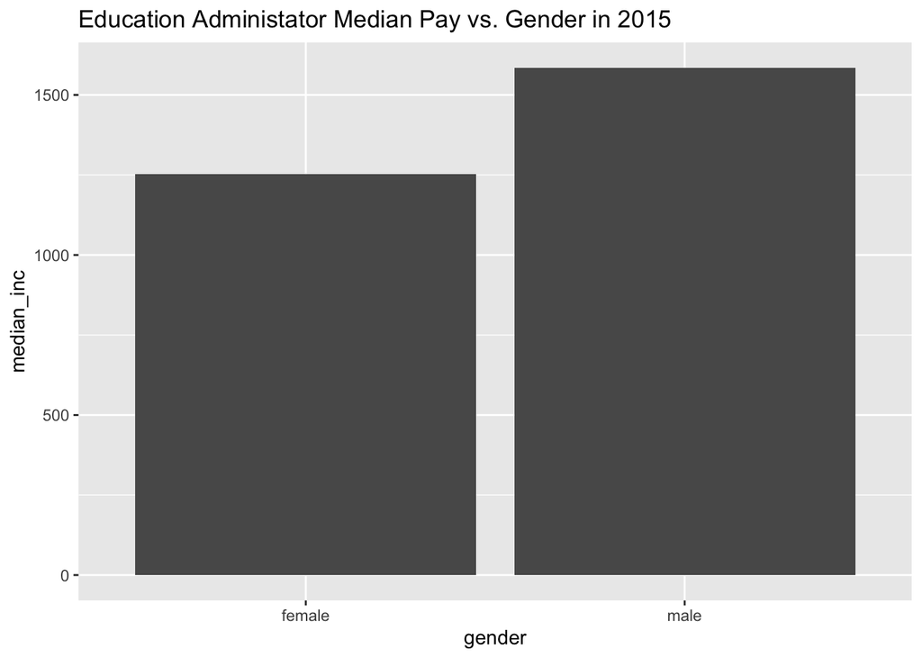

```r
data_E_A %>%
  ggplot(aes(x = gender, y = median_inc)) +
  geom_col() +
  ggtitle("Education Administator Median Pay vs. Gender in 2015")
```

Elementary and Middle School Teachers:

```r
data_S_T <- tibble(
  gender = c("female", "male"),
  no_people = c(2262, 543),
  median_inc = c(957, 1077)
)
```

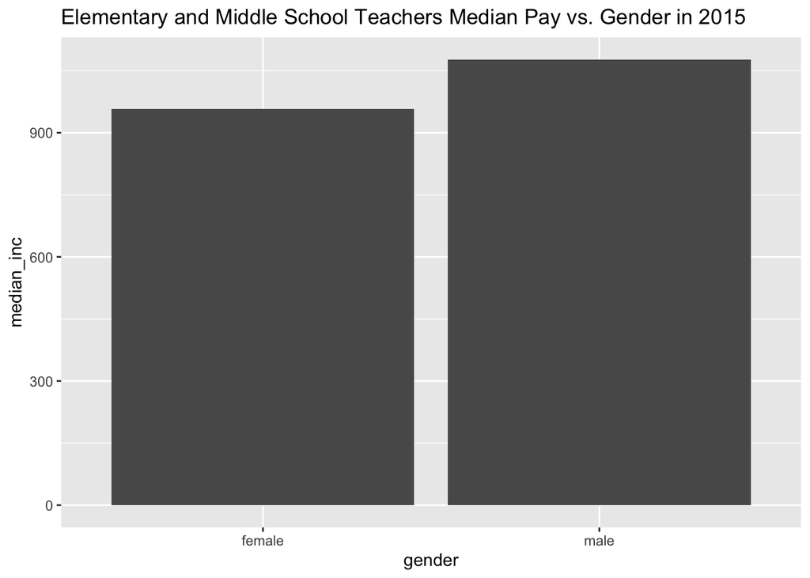

```r
data_S_T %>%
  ggplot(aes(x = gender, y = median_inc)) +
  geom_col() +
  ggtitle("Elementary and Middle School Teachers Median Pay vs. Gender in 2015")
```

Research Findings and Outcomes: In R Studio, we created a bar plot with gender on the x-axis and “median_inc,” median income on the y-axis for the group: Physicians and Surgeons and repeated the code for Nurses. As seen in the bar plot, there is a discrepancy in pay between male and female workers in both groups. In response to the first half of our research question: is there a pay gap in the medical field, particularly in the following professions: Physicians, Surgeons, and Nurses, our analysis confirms a disparity. Furthermore, in the bar plot for Physicians and Surgeons, there is approximately a $400 difference in weekly pay between male and female workers. For scale, $400 a week converts to a discrepancy of $1,600 a month, and $19,200 a year. At this rate, within five years, the difference would nearly amount to $96,000. For nurses, the disparity is approximately $124 in median weekly pay. Over the course of a month, the difference is $496. Within a year, the difference would be $5,952, and within five years, the disparity would amount to nearly $29,760. Additionally, we created bar plots for the median weekly income for male and female Education Administrators. We replicated the same code for Elementary and Middle School teachers. We did so to compare if the gender wage gap also existed within other fields to compare whether or not gender may be a contributing factor. Analyzing a gender wage gap in education catalyzed us to explore whether or not gender could be a contributing factor within the medical field.

Additionally, the article, “Cultural Constructions of Family Schemas: The Case of Women Finance Executives,” by Mary Blair Loy states that culturally held expectations of men and women’s inherent traits may lead to discrimination in the workplace. For example, women have been viewed as natural caregivers and men as breadwinners. This societal ideology can lead to the concentration of women and men in certain professions that align with “needing” specific characteristics in employees. Continuing, historically, there has been an association of caregiving with women, stating that women are inherently adept at this lower-ranking, “nurturing role.” In opposition, higher-risk professions like Physicians and Surgeons have been recognized as “more masculine.” Within the medical hierarchy, the Physician and Surgeon profession is ranked higher in prestige, pay, and competitiveness than in Nursing.

Although the article focuses on the Finance industry, it is possible that the same hegemony exists within the medical industry as well. Secondly, the research we conducted caused us to analyze why there are more men in the Physician and Surgeon role than women and why there are more women in Nursing than men. According to the article “Advancing Women in Healthcare Leadership: A Systematic Review and Meta-Synthesis of Multi-Sector Evidence on Organizational Interventions,” by the NIH, the study of medicine has been historically male-centric and placed barriers on women entering and advancing in the industry. These discrepancies persisted over time to create contemporary disparities. All in all, the synthesis of societal ideologies, historical factors, and gender discrimination are a few variables that have driven the gendered hierarchy within medicine and as a result, the discrepancy in pay.

Lastly, although our research focuses on these variables and how they contribute to the gender wage gap in the following medical professions: Physicians and Surgeons as one group and Nurses as another, we recognize the limitations of our discussion and conclusions. Though we argue the listed variables above are influential in the gender wage gap, there may be confounder variables additionally impacting the dynamic. The scope of our research is limited. Research findings and conclusions may transform with further analysis of external variables and their interaction with the research question.

Fortunately, there are efforts being done to possibly deal with the gender wage gap head on and one policy action that we view as being the most promising is the Equal Rights Amendment. This act states that “equality of rights under the law shall not be denied or abridged by the United States or by any state on account of sex.”. This amendment was proposed by Alice Paul in 1921 who sought to deal with the 19th amendment which gave women the right to vote but overall there has not been any significant policy put in place that can fully deal with gender discrimination by the federal or state governments. In general this act would directly deal with gender discrimination, including wage disparities, and bring more safeguards against discrimination. This is necessary because as we saw in our research, even in Nursing where women are the majority, they are still being paid less than men so clearly more safe guards and policy need to be put in place. Overall, when representatives or civil groups are pushing for any significant policy action to be taken for gender equality they should keep in mind how to deal with wages as one’s income can determine one’s future.

Discussion and Conclusion: In analyzing the literature review, our research question, and our findings and outcomes, we have come to the following conclusions. Based on our dataset, our research proves the existence of a gender pay gap in nursing, physicians, and surgeons. Although the dataset is sourced from a reputable database, the U.S Bureau of Labor Statistics has limitations on accurate collection. Therefore, our data might not be 100% representative of the populations analyzed. Furthermore, we acknowledge that our data was collected in 2015, and statistics may have changed throughout the subsequent years. The 2021 Physician Compensation Report, by Doximity, states the gender pay gap across sectors, including the medical field have closed; however, still persists. Though our dataset is not current, we recognize the imperativeness of understanding the historical trends of the gender pay gap to create robust solutions and initiatives in closing the gap.

Continuing, as stated above, our research confirms the existence of a gender pay gap in the medical field and argues the following contributing drivers stated above. However, we acknowledge that our explanations provided in this research do not fully capture the influential variables. It’s plausible that other external factors may have driven the skewing in the particular dataset analyzed in our research paper. Furthermore, it’s arguable that factors like the prestige of the hospital, gender differences in hospital applicants, varied hiring processes across hospitals, and availability of workers to relocate could have impacted the results. However, our study still showcases the impact of gender on earnings for men versus women. The pay discrepancy can impact workers beyond the workplace. The article “Women’s Work and the Gender Pay Gap” by the Economic Policy Institute, states continual underpayment can amount to overall life financial instability, lack of retirement security, limitations on career progression, degradation of mental health, increased stress, and stress-induced ailments.

The continuous underpayment of women can have devastating impacts in all other domains of life thereby reducing life quality. Furthermore, we conclude studies centered on illuminating discrepancies in gender equality are critical to the betterment of society as a whole. Our study within the field can be expanded upon by supplemental research. Replicating the research in different regions worldwide can provide a more comprehensive perspective on global gender inequity and provide opportunities to learn from countries with higher gender pay equality in the medical field. Continuing, replicating this research question across industries can enable researchers and readers to understand the industry-specific barriers and factors contributing to possible gender pay discrepancies. All in all, our research adds to the field of study while highlighting the work and inquiry needed to be conducted.

Bibliography:

U.S. Bureau of Labor Statistics. (2021, September 1). Earnings of full-time workers. U.S. Bureau of Labor Statistics. Retrieved March 13, 2023, from https://www.bls.gov/opub/reports/womens-earnings/2020/home.htm#:~:text=Most%20of%20the%20growth%20in,80%20to%2083%20percent%20range.

Howell, K. (2022, March 8). Closing the gender pay gap in real estate: Titans of industry recap. Chicago Association of REALTORS®. Retrieved March 13, 2023, from https://chicagorealtor.com/closing-the-gender-pay-gap-in-real-estate-titans-of-industry-recap/#:~:text=There%20are%2023.3%25%20fewer%20women,men%20in%20commercial%20real%20estate.

AAUW. (2022, December 8). The simple truth about the gender pay gap: Aauw report. Retrieved March 13, 2023, from https://www.aauw.org/resources/research/simple-truth/

Aragão, C. (2023, March 1). Gender pay gap in U.S. hasn’t changed much in two decades. Pew Research Center. Retrieved March 9, 2023, from https://www.pewresearch.org/fact-tank/2023/03/01/gender-pay-gap-facts/#:~:text=In%202022%2C%20women%20earned%20an,80%25%20as%20much%20as%20men.

Ganguli, I., Sheridan, B., Gray, J., Chernew, M., Rosenthal, M. B., & Neprash, H. (2020). Physician work hours and the gender pay gap — evidence from Primary Care. New England Journal of Medicine, 383(14), 1349–1357. https://doi.org/10.1056/nejmsa2013804 Apaydin, E.A., Chen, P.G.C. & Friedberg, M.W. Differences in Physician Income by Gender in a

Multiregion Survey. J GEN INTERN MED 33, 1574–1581 (2018). https://doi.org/10.1007/s11606-018-4462-2

Kim A. Weeden, Youngjoo Cha, & Mauricio Bucca. (2016). Long Work Hours, Part-Time Work,

and Trends in the Gender Gap in Pay, the Motherhood Wage Penalty, and the Fatherhood Wage Premium. RSF: The Russell Sage Foundation Journal of the Social Sciences, 2(4), 71–102. https://doi.org/10.7758/rsf.2016.2.4.03

Polan, R. M., Mattei, L. H., & Barber, E. L. (2022). The Motherhood Penalty in Obstetrics and

Gynecology Training. Obstetrics and gynecology, 139(1), 9–13. https://doi.org/10.1097/AOG.0000000000004633

Budig, M. J. (2014, September 2). The Fatherhood Bonus and the motherhood penalty: Parenthood and the gender gap in pay – Third way. – Third Way. Retrieved March 9, 2023, from https://www.thirdway.org/report/the-fatherhood-bonus-and-the-motherhood-penalty-parenthood-and-the-gender-gap-in-pay#daddy-bonus-how-fatherhood-raises-most-mens-wages

Newman, C., Templeton, K., & Chin, E. L. (2020). Inequity and Women Physicians: Time to Change Millennia of Societal Beliefs. The Permanente journal, 24, 1–6. https://doi.org/10.7812/TPP/20.024

Miller, C. C. (2014, September 6). The motherhood penalty vs. the fatherhood bonus. The New York Times. Retrieved March 13, 2023, from https://www.nytimes.com/2014/09/07/upshot/a-child-helps-your-career-if-youre-a-man.html

Cultural constructions of family schemas: The case of women finance … (n.d.). Retrieved March 13, 2023, from https://sociology.ucsd.edu/_files/people/blair-loy/cultconstrfamschemasgendsoc2001.pdf

Mousa, M., Boyle, J., Skouteris, H., Mullins, A. K., Currie, G., Riach, K., & Teede, H. J. (2021, August 12). Advancing Women in Healthcare Leadership: A systematic review and meta-synthesis of multi-sector evidence on organisational interventions. EClinicalMedicine. Retrieved March 13, 2023, from https://www.ncbi.nlm.nih.gov/pmc/articles/PMC8365436/

Mousa M;Boyle J;Skouteris H;Mullins AK;Currie G;Riach K;Teede HJ; (n.d.). Advancing Women in Healthcare Leadership: A systematic review and meta-synthesis of multi-sector evidence on organisational interventions. EClinicalMedicine. Retrieved March 13, 2023, from https://pubmed.ncbi.nlm.nih.gov/34430838/

What’s holding women in medicine back from leadership. Harvard Business Review. (2018, November 7). Retrieved March 13, 2023, from https://hbr.org/2018/06/whats-holding-women-in-medicine-back-from-leadership

Anakinmemer. (2022, February 9). Doximity 2021 compensation report. Student Doctor Network. Retrieved March 13, 2023, from https://forums.studentdoctor.net/threads/doximity-2021-compensation-report.1456976/

Jessica Schieder and Elise Gould. July 20. (n.d.). “Women’s work” and the gender pay gap: How discrimination, societal norms, and other forces affect women’s occupational choices-and their pay. Economic Policy Institute. Retrieved March 13, 2023, from https://www.epi.org/publication/womens-work-and-the-gender-pay-gap-how-discrimination-societal-norms-and-other-forces-affect-womens-occupational-choices-and-their-pay/

Leisenring, M. (2021, October 8). Women still have to work three months longer to equal what men earned in a year. Census.gov. Retrieved March 16, 2023, from https://www.census.gov/library/stories/2020/03/equal-pay-day-is-march-31-earliest-since-1996.html#:~:text=At%20the%20current%20rate%2C%20it,reaching%2081.6%20cents%20in%202018.